# Ford GoBike System

## by Aly Essam

## Investigation Overview

> - Bay Wheels is a regional public bicycle sharing system in California's San Francisco Bay Area. It is operated by Motivate in a partnership with the Metropolitan Transportation Commission and the Bay Area Air Quality Management District.
> - Bay Wheels is the first regional and large-scale bicycle sharing system deployed in California and on the West Coast of the United States. It was established as Bay Area Bike Share in August 2013.
> - As of January 2018, The Bay Wheels system had over 2,600 bicycles in 262 stations across San Francisco, East Bay and San Jose.

## Dataset Overview

> - There are 183412 rows in the fordgobike trips dataset.
> - The trips in the dataset have 16 variables (duration_sec, start_time, end_time, start_station_id, start_station_name, start_station_latitude, start_station_longitude, end_station_id, end_station_name, end_station_latitude ,end_station_longitude, bike_id, user_type, member_birth_year, member_gender and bike_share_for_all_trip)
> - There are 4646 bikes, 329 start and end stations

## Distribution of Trip Duration

> The majority of the trips lasts less than 10 minutes and the trips lasts from 1 to 100 minutes

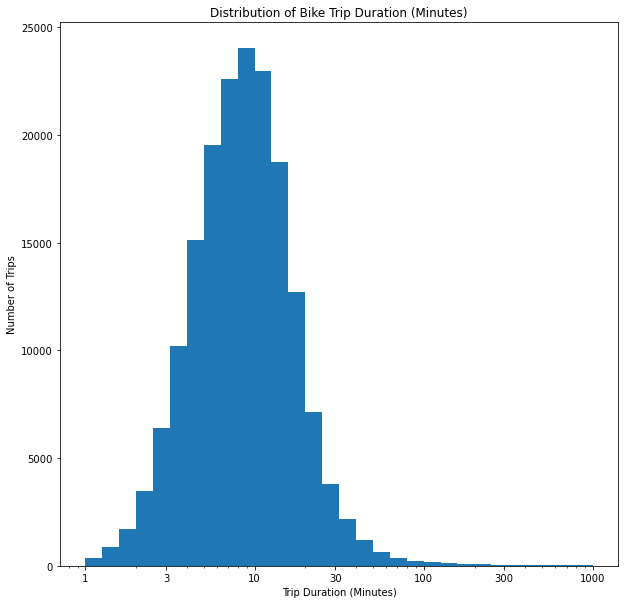

```python
bike_df['duration_min'] = bike_df['duration_sec'] / 60


plt.figure(figsize = (10,10))
ticks =  [ 1 , 3, 10, 30, 100, 300, 1000]
labels = ['{}'.format(v) for v in ticks]
bins_min = 10 ** np.arange(0, 3 + 0.1,0.1)
plt.hist(data = bike_df, x = 'duration_min', bins = bins_min);
plt.title('Distribution of Bike Trip Duration (Minutes)')
plt.xlabel('Trip Duration (Minutes)')
plt.ylabel('Number of Trips');
plt.xscale('log')
plt.xticks(ticks,labels);
```

## Trips per Hour Distribution

> According to the figures above, it is shown that
> - The most trips per hour are at 8:00 and 17:00 which they are the start and the end of the working day
> - The least trips per hour are from 0:00 to 5:00 when the users are asleep

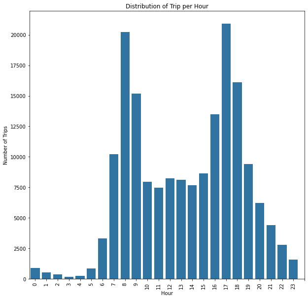

```python
plt.figure(figsize = (10,10))
base_color = sb.color_palette()[0]
sb.countplot(data = bike_df, x = 'Hour', color = base_color)
plt.title('Distribution of Trip per Hour')
plt.xlabel('Hour')
plt.ylabel('Number of Trips')
plt.xticks(range(0,25,1),rotation = 90);
```

## Relationship between Trips per hour and Average trip duration

> According to the figure above, It is shown that
> - The Average trip duration is almost the same except the time between 3:00 as it increased rapidly due to the low trips in this hour
> - There are a slight increase in the average duration during the working hours between 10:00 and 15:00

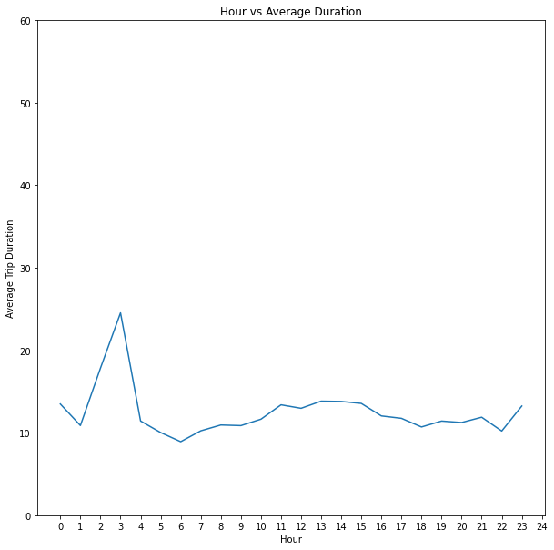

```python
plt.figure(figsize = (10,10))
hour_duration = bike_df.groupby(['Hour'])['duration_min'].mean()
hour_duration_df = hour_duration.reset_index()


sb.lineplot(x = hour_duration_df['Hour'], y = hour_duration_df['duration_min'])


plt.ylim(0,60)
plt.title('Hour vs Average Duration')
plt.xlabel('Hour')
plt.ylabel('Average Trip Duration') ;
plt.xticks(range(0,25,1)) ;
```

## Type of Users Distribution

> - There are two types of users : Subscribers and Customers
> - Most of the users are subscribers

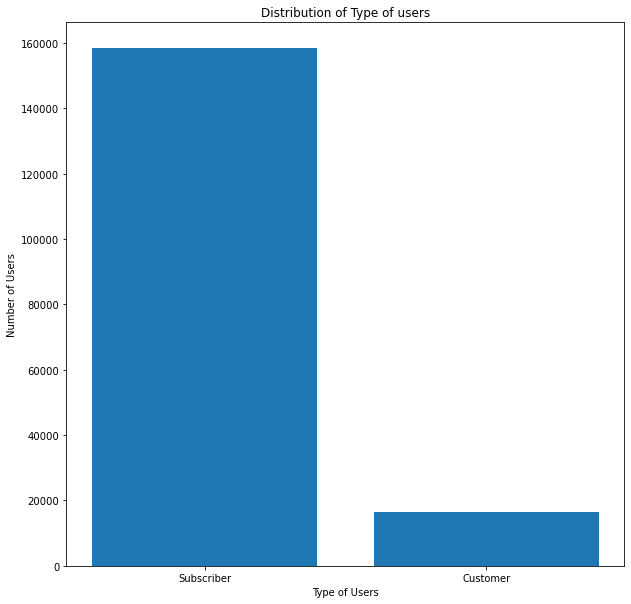

```python
plt.figure(figsize = (10,10))
plt.bar(x = bike_df['user_type'].value_counts().keys(), height = bike_df['user_type'].value_counts());
plt.title('Distribution of Type of users')
plt.xlabel('Type of Users')
plt.ylabel('Number of Users');
```

## Relationship between Type of Users and Duration

> - The customers have higher range of trip duration and higher median trip duration than the subscribers

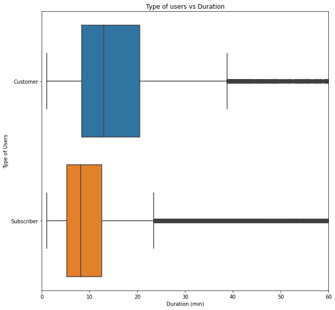

```python
plt.figure(figsize = (10,10))
sb.boxplot(data = bike_df, x = 'duration_min', y = 'user_type')

plt.xlim(0,60)
plt.title('Type of users vs Duration')
plt.xlabel('Duration (min)')
plt.ylabel('Type of Users') ;
```

## The impact of type of users, hour on duration

- The Average Trip duration for the customers through the hours of the day is much higher than the subscribers
- The Average trip duration increased rapidly at 3:00 due to the low trips in this hour

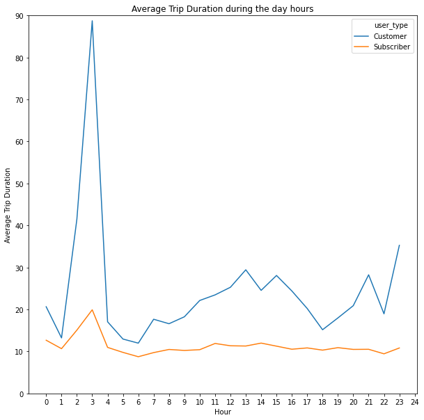

```python
plt.figure(figsize = (10,10))
hour_duration = bike_df.groupby(['Hour', 'user_type'])['duration_min'].mean()
hour_duration_df = hour_duration.reset_index()


sb.lineplot(x = hour_duration_df['Hour'], y = hour_duration_df['duration_min'], hue = hour_duration_df['user_type'] )


plt.ylim(0,90)
plt.title('Average Trip Duration during the day hours')
plt.xlabel('Hour')
plt.ylabel('Average Trip Duration') ;
plt.xticks(range(0,25,1)) ;
```

## Conclusion

> - The majority of the trips lasts less than 10 minutes and the trips lasts from 1 to 100 minutes
> - There are two types of users : Subscribers and Customers, Most of the users are subscribers
> - The customers have higher range of trip duration and higher median trip duration than the subscribers
> - The Average Trip duration for the customers through the hours of the day is much higher than the subscribers